# final_project

Students:

Gabriel Mauricio Molina

Vinícius Barros Alvarenga

```python
# Imports and the initial dataset
import numpy as np
import pandas as pd
import matplotlib.pyplot as plt

columns_names = ["price", "crime", "nox", "rooms", "dist", "radial", "proptax", "stratio", "lowstat", "lprice", "lnox", "lproptax"]
df=pd.read_csv("textfiles/hprice2.raw",delim_whitespace=True, header=None, names=columns_names)

df.head()
```

|  | price | crime | nox | rooms | dist | radial | proptax | stratio | lowstat | lprice | lnox | lproptax |
| --- | --- | --- | --- | --- | --- | --- | --- | --- | --- | --- | --- | --- |
| 0 | 24000 | 0.006 | 5.38 | 6.57 | 4.09 | 1 | 29.6 | 15.3 | 4.98 | 10.085810 | 1.682688 | 5.690360 |
| 1 | 21599 | 0.027 | 4.69 | 6.42 | 4.97 | 2 | 24.2 | 17.8 | 9.14 | 9.980402 | 1.545433 | 5.488938 |
| 2 | 34700 | 0.027 | 4.69 | 7.18 | 4.97 | 2 | 24.2 | 17.8 | 4.03 | 10.454500 | 1.545433 | 5.488938 |
| 3 | 33400 | 0.032 | 4.58 | 7.00 | 6.06 | 3 | 22.2 | 18.7 | 2.94 | 10.416310 | 1.521699 | 5.402678 |
| 4 | 36199 | 0.069 | 4.58 | 7.15 | 6.06 | 3 | 22.2 | 18.7 | 5.33 | 10.496790 | 1.521699 | 5.402678 |

# PART 1 - CROSS-SECTION DATA

This part uses the dataset HPRICE2.RAW described in HPRICE2.DES.

#### 1. State the fundamental hypothesis under which the Ordinary Least Squares (OLS) estimators are unbiased.

Given a linear model for two variables *y* and *x*, we will write a linear model that explains *y* in terms of *x*:

$$ y = \beta _0 +\beta_1x+u$$

Where $\beta_1$ is the cetteribus paribus effect, $\beta_0$ is the intercept parameter and $u$ is the error term, in another words, the "unobserved" aspects. To obtain this linear model we have to obtain $\beta_0$ and $\beta_1$. For this, we assume the fundamental Hyposthesis under which the Ordinary Least Squares (OLS) estimatores are unbiased, which is:

$$ E(u|x) = E(u) = 0$$

This assumptions says that the average of *u* in the population is zero. Also, it says how *u* and *x* are correlated, i.e., for any given value of x, the average of the unobservables is the same and therefore must equal the average value of *u* in the entire population, which is zero.

#### 2. Show that under this assumption the OLS estimators are indeed unbiased.

In this section, we will first find the estimators $\hat \beta_0$ and $\hat \beta_1$ of the coefficients $\beta_0$ and $\beta_1$, respectivaly, in the linear model. Then we will prove that these estimators are unbiased.

The linear model is given by:

$$ y = \beta_0 + \beta_1x + u $$

where $y$ is the dependent variable, $x$ is the independent variable, and $u$ is the error term.

To estimate the coefficients, we will use the Ordinary Least Squares (OLS) method. We assume that we have a sample of population $x_i$ and $y_i$, where $i = 1, 2, ..., n$ and $n$ is the number of observations. So we can write the above equation for the samples as:

The linear model equation for the samples is given by:

$$ y_i = \beta_0 + \beta_1x_i + u_i $$

Isolanting the error for each sample we have that:

$$ u_i = y_i - \beta_0 - \beta_1x_i $$

Now we use the fundamental hypothesis for the last exercice to derive the estimators.

$$E(u_i) = E(y_i - \beta_0 - \beta_1x_i) = 0 \quad\quad\quad\quad\quad$$

$$Cov(u_i,x_i) = E(x_i u_i) = E(x_i(y_i - \beta_0 - \beta_1x_i))= 0 \quad\quad\quad $$

Developing these equations by the definition of expectation follows that:

$$ n^{-1} \sum_{i=1}^{n}(y_i - \hat \beta_0 - \hat \beta_1x_i) = 0 \quad\quad\quad\quad\quad (i) $$

$$ n^{-1}\sum_{i=1}^{n}x_i(y_i - \hat \beta_0 - \hat \beta_1x_i) = 0 \quad\quad\quad\quad\quad (ii) $$

Opening the summation on $(i)$ we have that:

$$ \hat \beta_0 = \frac{1}{n}\sum_{i=1}^{n}y_i - \hat \beta_1 \frac{1}{n}\sum_{i=1}^{n}x_i $$

Wich can be written as:

$$ \hat \beta_0 = \bar y - \hat \beta_1 \bar x \quad\quad\quad\quad\quad (I)$$

Now, for the second expression $(ii)$ we drop the term $n^{-1}$ and substitute the value of $\hat \beta_0$ from $(I)$:

$$ \sum_{i=1}^{n}x_i(y_i - (\bar y - \hat \beta_1 \bar x )- \hat \beta_1x_i) = 0 $$

Which, upon rearrangement, gives:

$$ \sum_{i=1}^{n}x_i(y_i-\bar y) =\hat \beta_1 \sum_{i=1}^{n}x_i (x_i - \bar x) $$

From basic properties of the summation operator:

$\sum_{i=1}^{n}x_i(y_i-\bar y) =\sum_{i=1}^{n}(x_i-\bar x)(y_i-\bar y)$ and $ \sum_{i=1}^{n}x_i (x_i - \bar x) = \sum_{i=1}^{n}(x_i-\bar x)^2$

Then, we find that $\beta_1$ is:

$$ \hat \beta_1 = \frac{\sum_{i=1}^{n}(x_i - \bar x)(y_i - \bar y)}{\sum_{i=1}^{n}(x_i - \bar x)^2} \quad\quad\quad\quad\quad (II)$$

Finally, the OLS estimators are given by:

$$ \hat \beta_1 = \frac{\sum_{i=1}^{n}(x_i - \bar x)(y_i - \bar y)}{\sum_{i=1}^{n}(x_i - \bar x)^2} $$

$$ \hat \beta_0 = \bar y - \hat \beta_1 \bar x $$

where $n$ is the number of observations, $x_i$ and $y_i$ are the values of the independent and dependent variables, respectively, and $\bar x$ and $\bar y$ are the sample means of the independent and dependent variables, respectively.

Now, we can prove that those estimators are unbiased, for this we have to prove that $E(\hat \beta_1)=\beta_1$ and $E(\hat \beta_0)=\beta_0$.

We can rewrite the expression of $\hat \beta_1$ at $(II)$ using the fact that $\sum_{i=1}^{n}(x_i-\bar x)(y_i-\bar y)=\sum_{i=1}^{n}y_i(x_i-\bar x)$:

$$ \hat \beta_1 = \frac{\sum_{i=1}^{n}y_i(x_i-\bar x)}{\sum_{i=1}^{n}(x_i - \bar x)^2} $$

Using $s_x^2=\sum_{i=1}^{n}(x_i - \bar x)^2$ to simplify the notation and $ y_i = \beta_0 + \beta_1x_i + u_i $:

$$ \hat \beta_1 = \frac{\sum_{i=1}^{n}(x_i-\bar x)(\beta_0 + \beta_1x_i + u_i)}{s_x^2} $$

First, we open the numerator with the goal to simply it:

$$ \sum_{i=1}^{n}(x_i-\bar x)(\beta_0 + \beta_1x_i + u_i) = \sum_{i=1}^{n}(x_i-\bar x)\beta_0 + \sum_{i=1}^{n}(x_i-\bar x)\beta_1 x_i + \sum_{i=1}^{n}(x_i-\bar x) u_i = \beta_0 \sum_{i=1}^{n}(x_i-\bar x)+ \beta_1\sum_{i=1}^{n}(x_i-\bar x)x_i + \sum_{i=1}^{n}(x_i-\bar x)u_i $$

But, we have that:

$\sum_{i=1}^{n}(x_i-\bar x)=0$ and $\sum_{i=1}^{n}(x_i-\bar x)x_i = \sum_{i=1}^{n}(x_i-\bar x)^2=s_x^2$ so the numerator is: $\beta_1 s_x^2 + \sum_{i=1}^{n}(x_i-\bar x)u_i$

Which gives us the $\beta_1$:

$$ \hat \beta_1 = \beta_1 + \frac{\sum_{i=1}^{n}(x_i-\bar x)u_i}{s_x^2} $$

Now we can compute the expectated value of it:

$$ E(\hat \beta_1) = E(\beta_1) + E(\frac{\sum_{i=1}^{n}(x_i-\bar x)u_i}{s_x^2}) = \beta_1 +(\frac{1}{s_x^2})\sum_{i=1}^{n}E((x_i-\bar x)u_i) = \beta_1 +(\frac{1}{s_x^2})\sum_{i=1}^{n}E((x_i-\bar x))E(u_i) $$

But, as for our assumption $E(u_i)=0$, so $E(\hat \beta_1) = \beta_1$ and we conclude that $\hat \beta_1$ is unbiased.

For $\hat \beta_0$:

$$ E(\hat \beta_0) = E(\bar y - \hat \beta_1 \bar x) = E((\beta_0 + \beta_1 \bar x + \bar u) - \hat \beta_1 \bar x) = E(\beta_0 + (\beta_1 - \hat \beta_1)\bar x + \bar u) = \beta_0 + E((\beta_1 - \hat \beta_1)\bar x ) $$

As $E(\bar u)= 0$ and $E(\hat \beta_1) = \beta_1 $ we have that $E((\beta_1 - \hat \beta_1)\bar x ) = 0$ and $E(\hat \beta_0) = \beta_0$ and thus, $\hat \beta_0$ is unbiased

#### 3. Explain the sample selection bias with an example from the course.

Sample selection bias arises when the sample used does not adequately represent the entire population, leading to erroneous conclusions.

In our course, we examined the example of RAF warplanes during World War II. British engineers analyzed the returning planes to identify the most damaged areas and enhance their resilience in those spots. However, a critical issue emerged: the planes that were shot down were not included in the sample, and these aircraft often displayed extensive damage in specific areas. Consequently, the engineers' conclusions were skewed by this selection bias, as they were unable to identify the critical areas for reinforcement solely by examining the limited sample.

#### 4. Explain the omitted variable bias with an example from the course

The ommited variable bias occours when we ommit a variable that actually belongs in the true, population, model.

In the course we saw the example in which we were trying to explaing how the wage of a person can be explained by how many years of education the person has and the innate ability of that person, so our model should be like:

$$ wage = \beta_0 + \beta_1 educ + \beta_2 abil + u. $$

This model obtains $\beta_0$, $\beta_1$ and $\beta_2$ which are unbiased, i.e, we runned a regression in *educ* and *abil* and got these unbiased coeficients.

Although, imagine that for ignorance or data inavability we exclude $\beta_2$, running a regression with only *educ*, that gives us the following model:

$$ wage = \tilde{\beta}_0 + \tilde{\beta}_1 educ + v $$

In this new model we have that $v = \beta_2 abil + u$, and that $\tilde{\beta}_1 \neq \beta_1$. In fact, when we don't include the other variable in our regression we obtain, in general, an biased estimator $\tilde{\beta}_1$.

It can be shown that $ E(\tilde{\beta}_1) = \beta_1 + \tilde{\beta}_2 \tilde{\delta}_1$, where $\tilde{\delta}_1$ is the sample covariance between *educ* and *abil*. So $\tilde{\beta}_1$ is unbiased only if $\tilde{\delta}_1=0$, which means that *educ* and *abil* are uncorrelated.

In our example, in general, we believe that *educ* and *abil* are positive correlated and as more hability leads to higher productivity we have that $\beta_2 > 0$, so we conclude that the OLS estimators for the equation $wage = \tilde{\beta}_0 + \tilde{\beta}_0 educ + v$ are on average too large.

#### 5. Explain the problem of multicollinearity. Is it a problem in this dataset?

Multicolinearity occurs when we have a strong, but not perfect, correlation between two or more independent variables. For instance imagine that the variable $x_j$ has a strong, but not perfect, correlation with the others, this leads to a high variance of the estimator $\hat \beta_j$.

Also, if we have multicolliearity the matrix *X*, the matrix which the columns are the sample values for the independent variables, will be such that $det(X X^{-1})$ is equal or close to zero.

```python
X = df.copy()

det_x = np.linalg.det(X.T.dot(X))
print(det_x)

if det_x < 1e-10 and  det_x > -1e-10:
    print("There is multicollinearity in the data.")
else:
    print("There is no multicollinearity in the data.")
```

```
4.036293260468671e+42
There is no multicollinearity in the data.
```

#### 6. Create three categories of nox levels (low, medium, high), corresponding to the following percentiles: 0-39%, 40%-60%, 61%-100%

Firstly, we define the percentiles $ [0, 40, 61, 100] $, these will be used to divide the 'nox' column into categories (low, medium, high).

Secondly, with the numpy.percentile function, we calculate the specified percentiles for the 'nox' column in the DataFrame df that we have defined. It computes the values at the given percentiles and stores them in the nox_percentiles array.

Thirdly, creating a new column in the DataFrame called 'nox_category'. It uses numpy.where to assign categories ('low', 'medium', 'high') based on the conditions of the excersise. It checks if 'nox' is within certain ranges defined by the percentiles and assigns the corresponding category.

```python
# 1. Define the percentiles
percentiles = [0, 40, 61, 100]

# 2. Use numpy.percentile to calculate the specified percentiles for the 'nox' column
nox_percentiles = np.percentile(df['nox'], percentiles)

# 3. Create categories using numpy.where
df['nox_category'] = np.where((df['nox'] >= nox_percentiles[0]) & (df['nox'] <= nox_percentiles[1]), 'low',
                              np.where((df['nox'] > nox_percentiles[1]) & (df['nox'] <= nox_percentiles[2]), 'medium', 'high'))

# 4. Display the updated dataframe
df.head()
```

|  | price | crime | nox | rooms | dist | radial | proptax | stratio | lowstat | lprice | lnox | lproptax | nox_category |
| --- | --- | --- | --- | --- | --- | --- | --- | --- | --- | --- | --- | --- | --- |
| 0 | 24000 | 0.006 | 5.38 | 6.57 | 4.09 | 1 | 29.6 | 15.3 | 4.98 | 10.085810 | 1.682688 | 5.690360 | medium |
| 1 | 21599 | 0.027 | 4.69 | 6.42 | 4.97 | 2 | 24.2 | 17.8 | 9.14 | 9.980402 | 1.545433 | 5.488938 | low |
| 2 | 34700 | 0.027 | 4.69 | 7.18 | 4.97 | 2 | 24.2 | 17.8 | 4.03 | 10.454500 | 1.545433 | 5.488938 | low |
| 3 | 33400 | 0.032 | 4.58 | 7.00 | 6.06 | 3 | 22.2 | 18.7 | 2.94 | 10.416310 | 1.521699 | 5.402678 | low |
| 4 | 36199 | 0.069 | 4.58 | 7.15 | 6.06 | 3 | 22.2 | 18.7 | 5.33 | 10.496790 | 1.521699 | 5.402678 | low |

#### 7. Compute for each category of nox level the average median price and comment on your results

Firstly, we calculate the average price for each category of 'nox' concentration, for that we use "groupby" method in Pandas to group the DataFrame df by the values in the 'nox_category' column. We select the 'price' column and calculate the mean for each group. The result is a Pandas Series where each category of 'nox' has an associated average price.

Finally, we print the calculated average prices for each 'nox_category' to observe the relationship between nox levels and the average median housing price.

```python
# Calculate the average price for each 'nox_category'
grouped = df.groupby('nox_category')
average_price_by_nox_category = grouped['price'].mean()

# Display the results
average_price_by_nox_category
```

```
nox_category
high      18443.744792
low       27170.609524
medium    20613.432692
Name: price, dtype: float64
```

#### 8. Produce a scatter plot with the variable price on the y-axis and the variable nox on the x-axis. Is this a ceteris paribus effect?

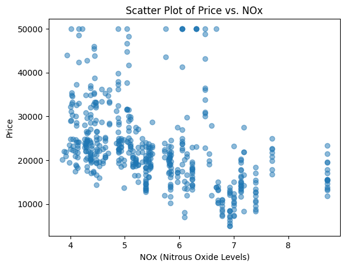

```python
# Importing necessary libraries
import matplotlib.pyplot as plt

# Scatter plot
plt.scatter(df['nox'], df['price'], alpha=0.5)
plt.title('Scatter Plot of Price vs. NOx')
plt.xlabel('NOx (Nitrous Oxide Levels)')
plt.ylabel('Price')
plt.show()
```

The ceteribus paribus effect mesures the effect of one variable on another when all others are constant.

The scatter plot doesn't measure this, we can't see that other variables are held constant, only the relations between various tuples of values of price and nox. This can show us if the variables have a correlation or not, and makes us able to mesure this quantity. But we can't see that there are or not another variables on the play with only this plot. So, we can't conclude anything with the scatter plot concerning the ceteribus paribus.

#### 9. Run a regression of price on a constant, crime, nox, rooms, proptax. Comment on the histogram of the residuals. Interpret all coefficients.

```
                            OLS Regression Results
==============================================================================
Dep. Variable:                  price   R-squared:                       0.575
Model:                            OLS   Adj. R-squared:                  0.572
Method:                 Least Squares   F-statistic:                     169.6
Date:                Tue, 12 Dec 2023   Prob (F-statistic):           1.06e-91
Time:                        22:02:26   Log-Likelihood:                -5119.6
No. Observations:                 506   AIC:                         1.025e+04
Df Residuals:                     501   BIC:                         1.027e+04
Df Model:                           4
Covariance Type:            nonrobust
==============================================================================
                 coef    std err          t      P>|t|      [0.025      0.975]
------------------------------------------------------------------------------
const      -1.868e+04   3215.205     -5.811      0.000    -2.5e+04   -1.24e+04
crime       -136.5438     38.529     -3.544      0.000    -212.241     -60.846
nox         -660.4672    314.634     -2.099      0.036   -1278.632     -42.303
rooms       7797.9286    404.345     19.285      0.000    7003.507    8592.350
proptax      -89.4144     23.966     -3.731      0.000    -136.500     -42.329
==============================================================================
Omnibus:                      264.796   Durbin-Watson:                   0.752
Prob(Omnibus):                  0.000   Jarque-Bera (JB):             2348.397
Skew:                           2.111   Prob(JB):                         0.00
Kurtosis:                      12.673   Cond. No.                         546.
==============================================================================

Notes:
[1] Standard Errors assume that the covariance matrix of the errors is correctly specified.
```

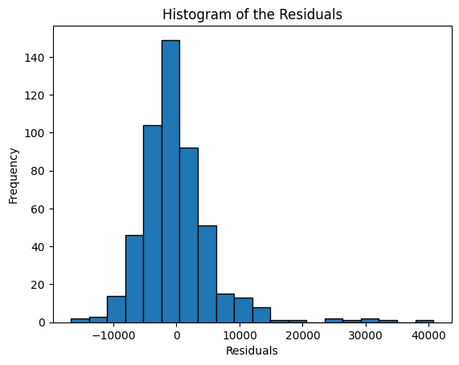

```python
import statsmodels.api as sm

# Define the dependent and independent variables
X = df[['crime', 'nox', 'rooms', 'proptax']]
y = df['price']

# Add a constant to the independent value
X = sm.add_constant(X)

# Adjust the regression model
model = sm.OLS(y, X)
results = model.fit()


print(results.summary())

# Compute the residuals
residuals = results.resid

plt.hist(residuals, bins=20, edgecolor='black')
plt.title('Histogram of the Residuals')
plt.xlabel('Residuals')
plt.ylabel('Frequency')
plt.show()
```

The histogram shows that the average of the residuals is zero, which aligns with our fundamental hypothesis. We can glimpse this as the value of 0 has the highest frequency.

Regarding the coefficients, we can interpret them as follows: Holding everything else constant, a one-unit increase in the crime variable results in a price decrease of 136.5438. Similarly, a one-unit increase in the nox variable leads to a price decrease of 660.4672. Likewise, a unit increase in the number of rooms translates to a price increase of 7797.9286. Finally, for the property tax, we observe a price decrease of 89.4144 units

#### 10. Run a regression of lprice on a constant, crime, nox, rooms, proptax. Comment on the histogram of the residuals. Interpret all coefficients.

```
                            OLS Regression Results
==============================================================================
Dep. Variable:                 lprice   R-squared:                       0.611
Model:                            OLS   Adj. R-squared:                  0.608
Method:                 Least Squares   F-statistic:                     196.9
Date:                Tue, 12 Dec 2023   Prob (F-statistic):          2.50e-101
Time:                        22:02:26   Log-Likelihood:                -26.367
No. Observations:                 506   AIC:                             62.73
Df Residuals:                     501   BIC:                             83.87
Df Model:                           4
Covariance Type:            nonrobust
==============================================================================
                 coef    std err          t      P>|t|      [0.025      0.975]
------------------------------------------------------------------------------
const          8.6550      0.137     63.320      0.000       8.386       8.924
crime         -0.0125      0.002     -7.641      0.000      -0.016      -0.009
nox           -0.0476      0.013     -3.557      0.000      -0.074      -0.021
rooms          0.2816      0.017     16.379      0.000       0.248       0.315
proptax       -0.0043      0.001     -4.184      0.000      -0.006      -0.002
==============================================================================
Omnibus:                      118.409   Durbin-Watson:                   0.764
Prob(Omnibus):                  0.000   Jarque-Bera (JB):              730.140
Skew:                           0.859   Prob(JB):                    2.83e-159
Kurtosis:                       8.629   Cond. No.                         546.
==============================================================================

Notes:
[1] Standard Errors assume that the covariance matrix of the errors is correctly specified.
```

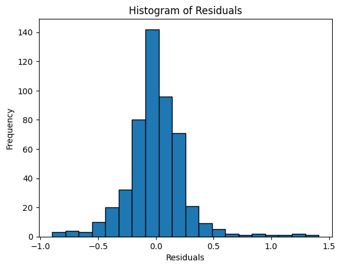

```python
import statsmodels.api as sm

# Define the dependent and independent variables
X = df[['crime', 'nox', 'rooms', 'proptax']]
y = df['lprice']

# Add a constant to the independent variables matrix
X = sm.add_constant(X)

# Fit the regression model
model = sm.OLS(y, X)
results = model.fit()

# Print the summary statistics of the model
print(results.summary())

# Calculate the residuals
residuals = results.resid

# Plot the histogram of the residuals
plt.hist(residuals, bins=20, edgecolor='black')
plt.title('Histogram of Residuals')
plt.xlabel('Residuals')
plt.ylabel('Frequency')
plt.show()
```

The histogram shows that the average of the residuals is zero, which is what our fundamental hiphotesys says. We can have a glipsy of it as we see that the value of 0 is the one that has more frequency.

Regarding the coefficients, we can interpret them as follows: Holding everything else constant, a one-unit increase in the crime variable results in a log price decrease of 0.0125. Similarly, a one-unit increase in the nox variable leads to a log price decrease of 0.0476. Likewise, a unit increase in the number of rooms translates to a log price increase of 0.2816 . Finally, for the property tax, we observe a log price decrease of 0.0043 units

#### 11. Run a regression of lprice on a constant, crime, lnox, rooms, lproptax. Comment on the histogram of the residuals. Interpret all coefficients.

```
                            OLS Regression Results
==============================================================================
Dep. Variable:                 lprice   R-squared:                       0.612
Model:                            OLS   Adj. R-squared:                  0.609
Method:                 Least Squares   F-statistic:                     197.4
Date:                Tue, 12 Dec 2023   Prob (F-statistic):          1.77e-101
Time:                        22:02:26   Log-Likelihood:                -26.021
No. Observations:                 506   AIC:                             62.04
Df Residuals:                     501   BIC:                             83.18
Df Model:                           4
Covariance Type:            nonrobust
==============================================================================
                 coef    std err          t      P>|t|      [0.025      0.975]
------------------------------------------------------------------------------
const          9.7505      0.253     38.476      0.000       9.253      10.248
crime         -0.0128      0.002     -8.002      0.000      -0.016      -0.010
lnox          -0.2769      0.077     -3.591      0.000      -0.428      -0.125
rooms          0.2802      0.017     16.282      0.000       0.246       0.314
lproptax      -0.1779      0.042     -4.215      0.000      -0.261      -0.095
==============================================================================
Omnibus:                      116.110   Durbin-Watson:                   0.768
Prob(Omnibus):                  0.000   Jarque-Bera (JB):              716.737
Skew:                           0.838   Prob(JB):                    2.30e-156
Kurtosis:                       8.585   Cond. No.                         241.
==============================================================================

Notes:
[1] Standard Errors assume that the covariance matrix of the errors is correctly specified.
```

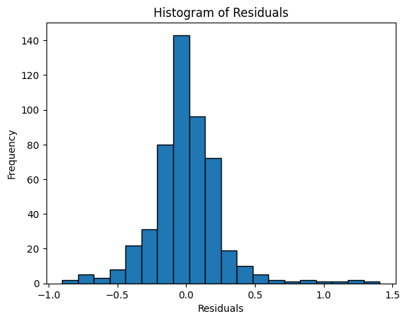

```python
import statsmodels.api as sm

# Define the dependent and independent variables
X = df[['crime', 'lnox', 'rooms', 'lproptax']]
y = df['lprice']

# Add a constant to the independent variables matrix
X = sm.add_constant(X)

# Fit the regression model
model = sm.OLS(y, X)
results = model.fit()

# Print the summary statistics of the model
print(results.summary())

# Calculate the residuals
residuals = results.resid

# Plot the histogram of the residuals
plt.hist(residuals, bins=20, edgecolor='black')
plt.title('Histogram of Residuals')
plt.xlabel('Residuals')
plt.ylabel('Frequency')
plt.show()
```

The histogram shows that the average of the residuals is zero, which is what our fundamental hiphotesys says. We can have a glipsy of it as we see that the value of 0 is the one that has more frequency.

Regarding the coefficients, we can interpret them as follows: Holding everything else constant, a one-unit increase in the crime variable results in a log price decrease of 0.0128. Similarly, a one-unit increase in the log nox variable leads to a log price decrease of0.2769. Likewise, a unit increase in the number of rooms translates to a log price increase of 0.2802 . Finally, for the log property tax, we observe a log price decrease of 0.1779 units

#### 12. In the specification of question 10, test the hypothesis $ H_0: \beta_{nox} >0 $ vs. $H_1: \beta_{nox} < 0$ at the 10% level

```python
import statsmodels.api as sm
from scipy.stats import t

# Run the regression model
X = df[['crime', 'nox', 'rooms', 'proptax']]
X = sm.add_constant(X)
y = df['lprice']

model = sm.OLS(y, X).fit()
beta_nox = model.params['nox']
se_nox = model.bse['nox']

# t-statistic
t_value = beta_nox / se_nox
deg_freedom = len(y) -len(model.params)-2
print(f't-statistic: {t_value:.4f}')

# One-sided p-value
p_value_one_tailed = t.sf(abs(t_value), deg_freedom)
alpha = 0.10  # Adjusted alpha level for a one-sided test

# Compare the p-value with the significance level
if p_value_one_tailed < alpha:
    print(f'Reject the null hypothesis. p-value: {p_value_one_tailed:.4f}')
else:
    print(f'Fail to reject the null hypothesis. p-value: {p_value_one_tailed:.4f}')
```

```
t-statistic: -3.5570
Reject the null hypothesis. p-value: 0.0002
```

#### 13. In the specification of question 10, test the hypothesis $H_0: \beta_{nox} = 0$ vs. $H_1: \beta_{nox} ≠ 0$ at the 10% level using the p-value of the test

```python
import statsmodels.api as sm
from scipy.stats import f

# Define the dependent and independent variables
X = df[['crime', 'nox', 'rooms', 'proptax']]
y = df['lprice']

# Add a constant to the independent variables matrix
X = sm.add_constant(X)

# Fit the regression model
model = sm.OLS(y, X)
results = model.fit()

# Calculate the t-statistic of the 'nox' coefficient
t_value_nox = results.params['nox'] / results.bse['nox']

p_value_nox = 2*t.sf(abs(t_value_nox), len(y) - len(results.params) - 2)

# Display the results
print("P-value:", p_value_nox)

if p_value_nox < 0.1:
    print("Reject the null hypothesis.")
else:
    print("Fail to reject the null hypothesis.")
```

```
P-value: 0.0004108428885706018
Reject the null hypothesis.
```

#### 14. In the specification of question 10, test the hypothesis $ H_0: \beta_{crime} = \beta_{proptax} $ at the 1% level

```python
import statsmodels.api as sm

# We will define a new variable theta = Beta_crime - Beta_proptax
# The new model is:
# lprice = Beta_0 + Beta_nox * nox + Beta_rooms * rooms + (teta+Beta_proptax)*crime+Beta_proptax*proptax + u
# lprice = Beta_0 + Beta_nox * nox + Beta_rooms * rooms + teta*crime + Beta_proptax*(crime+proptax) + u
# Then we will test the null hypothesis that theta = 0


# Run the regression model
df['crime_proptax'] = df['crime'] + df['proptax']
X = df[['crime', 'nox', 'rooms', 'crime_proptax']]
X = sm.add_constant(X)
y = df['lprice']

model = sm.OLS(y, X)
results = model.fit()

# calculate the t-statistic
t_value = results.params['crime'] / results.bse['crime']

# calculate the p-value for a two-sided test
p_value = 2*t.sf(abs(t_value), results.df_resid)

print("p_value:", p_value)

alpha = 0.01
if p_value < alpha:
    print("Reject the null hypothesis")
else:
    print("Fail to reject the null hypothesis")
```

```
p_value: 0.0003202080646099709
Reject the null hypothesis
```

#### 15. In the specification of question 10, test the hypothesis $H_0: \beta_{nox} = 0, \beta_{proptax} = 0$ at the 1% level

```python
import statsmodels.api as sm
from scipy.stats import f

# Define the dependent and independent variables
X = df[['crime', 'nox', 'rooms', 'proptax']]
y = df['lprice']

# Add a constant to the independent variables matrix
X = sm.add_constant(X)

# Fit the regression model
model = sm.OLS(y, X)
results = model.fit()

# Calculate the sum of squared errors for the unconstrained model
u = results.resid
SSR0 = u.T @ u

# Create the constrained model by setting 'nox' and 'proptax' coefficients to 0
X_constrained = df[['crime', 'rooms']]

# Fit the constrained regression model
model_constrained = sm.OLS(y, X_constrained)
results_constrained = model_constrained.fit()

# Calculate the sum of squared errors for the constrained model
u_constrained = results_constrained.resid
SSR1 = u_constrained.T @ u_constrained

# Calculate the F-statistic and p-value for a two-sided test
n = len(y)
k = len(results.params) - 1
F = ((SSR1 - SSR0) / 2) / (SSR0 / (n - k-1))
p_value = 2*f.sf(F, 2, n - k-1)

# Display the results
print("P-value:", p_value)

if p_value < 0.01:
    print("Reject the null hypothesis.")
else:
    print("Fail to reject the null hypothesis.")
```

```
P-value: 3.1958288131619834e-275
Reject the null hypothesis.
```

#### 16. In the specification of question 10, test the hypothesis $H_0: \beta_{nox} = -500, \beta_{proptax} = -100$ at the 1% level using the p-value of the test

```python
from scipy import stats

# Original model with all the variables from question 10, unrestricted model:

X_ur = df[['crime', 'rooms', 'nox', 'proptax']]
y_ur = df['lprice']

X_ur = sm.add_constant(X_ur)

model = sm.OLS(y_ur, X_ur)
results = model.fit()

# Calculate SSR0 for the model with Bnox and Bproptax
u = results.resid
SSR_ur = u.T @ u

# Calculate the degrees of freedom

df_ur = len(y_ur)-len(results.params)-2

# Model without Bnox and Bproptax, restricted model:

X_r = df[['crime', 'rooms']]
y_r = df['lprice']+500*df['nox']+100*df['proptax']

X_r = sm.add_constant(X_r)

model = sm.OLS(y_r, X_r)
results = model.fit()

# Calculate SSR1 for the model whitout Bnox and Bproptax

u = results.resid
SSR_r = u.T @ u

# Calculate the degrees of freedom

df_r = len(y_r)-len(results.params)-2

#  Calculate the F-statistic
q = df_r - df_ur
F = ((SSR_r-SSR_ur)/q)/(SSR_ur/(df_ur))

# Calculate the p-value for a two-sided test

p_value = 2*stats.f.sf(F, q, df_ur)

print("p-value: ", p_value)

if p_value < 0.1:
    print("Reject the null hypothesis")
else:
    print("Do not reject the null hypothesis")
```

```
p-value:  0.0
Reject the null hypothesis
```

#### 17. In the specification of question 10, test the hypothesis $H_0: \beta_{nox} + \beta_{proptax} = -1000$ at the 1% level using the p-value of the test

```python
from scipy.stats import t
# we have the original model:  lprice = B0 + Bcrime*crime + Brooms*rooms + Bnox*nox + Bproptax*proptax + u
# we want to test the null hypothesis Bnox + Bproptax = -1000
# we call theta = Bnox + Bproptax
# Then, we subitute theta in the model and we have:
# lprice = B0 + Bcrime*crime + Brooms*rooms + (theta - Bproptax)*nox + Bproptax*proptax + u
# which gives us:
# lprice = B0  + Bcrime*crime + Brooms*rooms + theta*nox + Bproptax*(proptax - nox) +  u
# we can see that the null hypothesis is equivalent to theta = -1000
# for this, we use the static t = (theta - (-1000))/std(theta)

# We contruct our model:

# Create the column'proptax_nox'
df['proptax_nox'] = df['proptax'] - df['nox']

# Create the matrix of independent variables
X = sm.add_constant(df[['crime', 'rooms', 'nox', 'proptax_nox']])
y = df['lprice']

model = sm.OLS(y, X)
results = model.fit()

# Compute t statistic
aj = -1000

coef_nox = results.params['nox']
std_nox = results.bse['nox']
t_value = (coef_nox-aj)/std_nox

# Compute the p-value (two-sided test)
degrees_of_freedom = len(y)-len(results.params)-2

p_value = 2 * t.sf(abs(t_value), degrees_of_freedom)
print("p-value: ", p_value)

# Compute the test of 1% significance level

if p_value < 0.01:
    print("Reject the null hypothesis")
else:
    print("Do not reject the null hypothesis")
```

```
p-value:  0.0
Reject the null hypothesis
```

#### 18. In the specification of question 10, test the hypothesis that all coefficients are the same for observations with low levels of nox vs. medium and high levels of nox.

```python
# Estimate the coefficient for low levels of nox
x_unrestricted = df[df['nox_category'] == 'low'][[
    'crime', 'nox', 'rooms', 'proptax']]
x_unrestricted = sm.add_constant(x_unrestricted)

y_unrestricted = df[df['nox_category'] == 'low']['lprice']

model = sm.OLS(y_unrestricted, x_unrestricted)
results_unrestricted = model.fit()

# we know the coefficients and we can make the hypothesis test for medium and high levels of nox
# H_0: b_i_low = b_i_high_medium \forall i
# H_1: b_i_low != b_i_high_medium \exists i

# Unrestricted model:
# lprice = beta0 + beta1 * crime + beta2 * nox + beta3 * rooms + beta4 * proptax + u
#
# Restricted model:
# lprice - beta1 * crime - beta2 * nox - beta3 * rooms - beta4 * proptax + = beta0 + u
# where beta_n is the result of the unrestricted model

x_medium_high = df[df['nox_category'] != 'low'][[
    'crime', 'nox', 'rooms', 'proptax']]
y_medium_high = df[df['nox_category'] != 'low']['lprice']

x_restricted = sm.add_constant(x_medium_high)[['const']]
y_restricted = y_medium_high - results_unrestricted.params['crime'] * x_medium_high['crime'] \
    - results_unrestricted.params['nox'] * x_medium_high['nox']\
    - results_unrestricted.params['rooms'] * x_medium_high['rooms'] \
    - results_unrestricted.params['proptax'] * x_medium_high['proptax']

model_restricted = sm.OLS(y_restricted, x_restricted)
results_restricted = model_restricted.fit()

# Compute the test:
SSR_unrestricted = results_unrestricted.ssr
SSR_restricted = results_restricted.ssr

k_unrestricted = x_unrestricted.shape[1] - 1
k_restricted = x_restricted.shape[1] - 1

q = k_unrestricted - k_restricted  # numerator degrees of freedom

n = len(y)
ddf = n - k_unrestricted - 1  # denominator degrees of freedom

F_statistic = ((SSR_restricted - SSR_unrestricted) / q) / \
    (SSR_unrestricted / ddf)


alpha = 0.10  # 10% significance level
p_value = stats.f.sf(F_statistic, q, ddf)

print("p-value: ", p_value)

if p_value < alpha:
    print("Reject the null hypothesis")
else:
    print("Do not reject the null hypothesis")
```

```
p-value:  5.1126e-320
Reject the null hypothesis
```

#### 19. Repeat the test of question 18 but now assuming that only the coefficients of nox and proptax can change between the two groups of observations. State and test $H_0$.

```python
import statsmodels.api as sm
from scipy import stats

# Unrestricted Model (Low NOX Group)
x_unrestricted = df[df['nox_category'] == 'low'][['crime', 'nox', 'rooms', 'proptax']]
x_unrestricted = sm.add_constant(x_unrestricted)
y_unrestricted = df[df['nox_category'] == 'low']['lprice']

model_unrestricted = sm.OLS(y_unrestricted, x_unrestricted)
results_unrestricted = model_unrestricted.fit()

# Restricted Model (Medium and High NOX Group)
x_medium_high = df[df['nox_category'] != 'low'][['crime', 'rooms']]
x_medium_high = sm.add_constant(x_medium_high)
y_medium_high = df[df['nox_category'] != 'low']['lprice']

# Adjust y_medium_high by subtracting the impact of nox and proptax
y_adjusted = y_medium_high - results_unrestricted.params['nox'] * df[df['nox_category'] != 'low']['nox'] \
    - results_unrestricted.params['proptax'] * df[df['nox_category'] != 'low']['proptax']

model_restricted = sm.OLS(y_adjusted, x_medium_high)
results_restricted = model_restricted.fit()

# F-test
SSR_unrestricted = results_unrestricted.ssr
SSR_restricted = results_restricted.ssr

k_unrestricted = x_unrestricted.shape[1] - 1
k_restricted = x_medium_high.shape[1] - 1

q = k_unrestricted - k_restricted  # numerator degrees of freedom

n = len(y_unrestricted) + len(y_medium_high)  # total number of observations
ddf = n - k_unrestricted - 1  # denominator degrees of freedom

F_statistic = ((SSR_restricted - SSR_unrestricted) / q) / (SSR_unrestricted / ddf)
p_value = stats.f.sf(F_statistic, q, ddf)

print("p-value: ", p_value)

if p_value < 0.10:
    print("Reject the null hypothesis")
else:
    print("Do not reject the null hypothesis")
```

```
p-value:  8.307101721771328e-263
Reject the null hypothesis
```

The obtained p-value of $8.31e-263$ is extremely close to zero, which is significantly less than the commonly chosen significance level of 0.10. Therefore, we reject the null hypothesis (H0).

### Interpretation:

*Null Hypothesis ((H_0)):* $[ \beta_{\text{nox,low}} = \beta_{\text{nox,medium/high}} ]$ & $[ \beta_{\text{proptax,low}} = \beta_{\text{proptax,medium/high}} ]$

*Alternative Hypothesis ((H_1)):* $[ \beta_{\text{nox,low}} \neq \beta_{\text{nox,medium/high}}]$ & $[ \beta_{\text{proptax,low}} \neq \beta_{\text{proptax,medium/high}} ]$

we reject the null hypothesis and conclude that there is sufficient evidence to suggest that the coefficients for $nox$ and/or $proptax$ differ between the group with low levels of $nox$ and the medium and high NOX groups.

# PART 2 - HETEROSKEDASTICITY

#### 20. Explain the problem of heteroskedasticity with an example of the course.

The heteroskedasticity happens when the homoskedasticity assumption is violeted. This assumption says that the unonbserved error variance don't vary with respect to the independent variables, i.e, $var(u)$ is constant when $x_1, x_2, ...$ vary. So, when we have heteroskedasticity, $var(u|x_1, x_2, ...)$ vary.

In one of our course examples, we explored the relationship between house prices and other variables. This scenario illustrates heteroscedasticity. For instance, the variance of the error in predicting house prices via the regression model could fluctuate with the house's square footage. A smaller house might exhibit relatively stable error variance in price prediction. However, as the house size increases, we observe a larger variation in the error between the predicted and actual prices. This variability complicates the estimation of parameters using Ordinary Least Squares (OLS) since it assumes homoscedasticity.

#### 21. Suppose that $ E(u u')= \sigma^2 \Omega$. Show that the GLS estimator is the best linear unbiased estimator.

Firstly, considering the model $y = X \beta + u$, where $E(u|X) = 0$, we derive the expression of the OLS estimator $b$. With a set of $n$ i.i.d. observations, the collected data is represented by the following equation:

$$ y = X b + u $$

To derive an expression for $b$, we minimize the sum of the squared residuals. Initially, we isolate the expression for $u$ and then compute its transpose, facilitating the minimization of $u' u$:

$$ u = y - X b \Rightarrow u' = (y - X b)' = y' - b' X' $$

Thus, the objective function to minimize becomes:

$$ u' u = (y' - b' X')(y - X b) = y'y - y'Xb - b'X'y + b'X'Xb $$

Recognizing that $b'X'y = (b'X'y)' = y'Xb$, we get:

$$ \text{min } u'u = y'y - 2b'X'y + b'X'Xb $$

Finally, the partial derivative of the equation with respect to $b$ and setting it to zero yields:

$$ \frac{\partial}{\partial b} (u'u) = 0 \Rightarrow -2X'y + 2X'Xb = 0 \Rightarrow X'Xb = X'y \Rightarrow b = (X'X)^{-1}X'y $$

After computing the estimator, to show that it is the Best Linear Unbiased Estimator (BLUE), we verify its linearity and unbiasedness. Linearity is evident in the linear relationship between $b$ and the dependent variable $y$. Next, we assess its unbiasedness by computing its expected value:

$$ E(b) = E((X'X)^{-1}X'y) = (X'X)^{-1}X'E(y) $$

Since $E(u|X) = 0$, then $E(y) = X \beta$, and we can rewrite $E(b)$ as:

$$ E(b) = (X'X)^{-1}(X'X) \beta \Rightarrow E(b) = \beta $$

This shows that the estimator $b$ is unbiased.

For further analysis, it's helpful to rewrite the expression of $b$ as:

$$ \left.\begin{matrix} y = X \beta + u \\ b = (X'X)^{-1}X'y \end{matrix}\right\}\Rightarrow b = \beta + (X'X)^{-1}X'u $$

Moving on to compute the variance of the estimator considering Heteroskedasticity, assuming $Var(u) = E(uu') = \sigma^{2}\Omega$:

$$ \begin{align*} Var(b) &= Var\left(\beta + (X'X)^{-1}X'u\right) \\ &= Var\left((X'X)^{-1}X'u\right) \\ &= (X'X)^{-1}X' Var(u) X(X'X)^{-1} \\ &= (X'X)^{-1}X' \sigma^{2} \Omega X(X'X)^{-1} \end{align*} $$

Therefore, the resulting equation contains the variance of the estimator, considering Heteroskedasticity:

$$ Var(b) = \sigma^{2} (X'X)^{-1}X' \Omega X(X'X)^{-1} $$

Utilizing Aitken's Theorem, which states that "The GLS estimator is BLUE," we conclude the proof.

#### 22. In the specification of question 9, test the hypothesis of no heteroskedasticity of linear form, i.e. in the regression of $u^2$ on constant, crime, nox, rooms, proptax, test H0: $\delta_{crime}$ , $\delta_{nox}$, $\delta_{room}$ , $\delta_{proptax}$ = 0, where the coefficients $\delta_{k}$ (k = crime, nox, rooms, proptax) are associated with the corresponding explanatory variables.

```python
# First, we construct the model of question 10:
# price = B0 + Bcrime*crime + Brooms*rooms + Bnox*nox + Bproptax*proptax + u
X = sm.add_constant(df[['crime', 'rooms', 'nox', 'proptax']])
y = df['price']

model = sm.OLS(y, X)
results = model.fit()

# Now, we construct the regression model for the residuals of the previous model:
# u^2 = delta0 +delta_crime*crime + delta_rooms*rooms + delta_nox*nox + delta_proptax*proptax +  v

u = results.resid
u2 = u**2
y = u2

model = sm.OLS(y, X)
results = model.fit()

# Now, we compute the test of 5% significance level

F = results.fvalue
k = 4
n = len(df)
degrees_of_freedom = n - k - 1

p_value = stats.f.sf(F, k, degrees_of_freedom)

print("p-value: ", p_value)

if p_value < 0.05:
    print("Reject the null hypothesis: There is heteroskedasticity")
else:
    print("Do not reject the null hypothesis: There is homoskedasticity")
```

```
p-value:  2.4672073438895583e-05
Reject the null hypothesis: There is heteroskedasticity
```

#### 23. In the specification of question 10, test the hypothesis of no heteroskedasticity of linear form

```python
# First, we construct the model of question 10:
# lprice = B0 + Bcrime*crime + Brooms*rooms + Bnox*nox + Bproptax*proptax + u
X = sm.add_constant(df[['crime', 'rooms', 'nox', 'proptax']])
y = df['lprice']

model = sm.OLS(y, X)
results = model.fit()

# Now, we construct the regression model for the residuals of the previous model:
# u^2 = delta0 +delta_crime*crime + delta_rooms*rooms + delta_nox*nox + delta_proptax*proptax +  v

u = results.resid
u2 = u**2
y = u2

model = sm.OLS(y, X)
results = model.fit()

# Now, we compute the test of 5% significance level

F = results.fvalue
k = 4
n = len(df)
degrees_of_freedom = n - k - 1

p_value = stats.f.sf(F, k, degrees_of_freedom)

print("p-value: ", p_value)

if p_value < 0.05:
    print("Reject the null hypothesis: There is heteroskedasticity")
else:
    print("Do not reject the null hypothesis: There is homoskedasticity")
```

```
p-value:  8.32991112838834e-14
Reject the null hypothesis: There is heteroskedasticity
```

#### 24. In the specification of question 11, test the hypothesis of no heteroskedasticity of linear form

```python
# First, we construct the model of question 10:
# lprice = B0 + Bcrime*crime + Brooms*rooms + Blnox*lnox + Blproptax*lproptax + u
X = sm.add_constant(df[['crime', 'rooms', 'lnox', 'lproptax']])
y = df['lprice']

model = sm.OLS(y, X)
results = model.fit()

# Now, we construct the regression model for the residuals of the previous model:
# u^2 = delta0 +delta_crime*crime + delta_rooms*rooms + delta_lnox*lnox + delta_lproptax*lproptax +  v

u = results.resid
u2 = u**2
y = u2

model = sm.OLS(y, X)
results = model.fit()

# Now, we compute the test of 5% significance level

F = results.fvalue
k = 4
n = len(df)
degrees_of_freedom = n - k - 1

p_value = stats.f.sf(F, k, degrees_of_freedom)

print("p-value: ", p_value)

if p_value < 0.05:
    print("Reject the null hypothesis: There is heteroskedasticity")
else:
    print("Do not reject the null hypothesis: There is homoskedasticity")
```

```
p-value:  1.0205916389181023e-12
Reject the null hypothesis: There is heteroskedasticity
```

#### 25. Comment on the differences between your results of questions 22,23, 24.

Heteroscedasticity is evident across all questions addressed. The transformations applied from one question to another primarily involved taking the logarithm of a variable, whether it was independent or not. This approach aimed to mitigate the overall impact of heteroscedasticity. However, it didn't yield a model free of this issue. Consequently, we can infer that the disparities persist in the variables used, despite yielding largely similar outcomes.

#### 26. Regardless of the results of the test of question 22, identify the most significant variable causing heteroskedasticity using the student statistics and run a WLS regression with the identified variable as weight.

```python
# First, we construct the model of question 10, beggining with the model of question 11:
X = sm.add_constant(df[['crime', 'rooms', 'nox', 'proptax']])
y = df['price']

model = sm.OLS(y, X)
results = model.fit()

# Now, we construct the regression model for the residuals of the previous model:
u = results.resid
u2 = u**2
y = u2

model = sm.OLS(y, X)
results = model.fit()

alpha = 0.1
print('*'*50)
print('Variables causing heteroskedasticity:')
for i, coef in enumerate(results.params.index):
    p_value = results.pvalues.iloc[i]
    if p_value < alpha:
        print(f'{coef} - p-value: {p_value:.4f}')
print('*'*50)

# Run the WLS regression modelS

weights = 1/(results.fittedvalues**2)

wls_model = sm.WLS(y, X, weights=weights)
wls_results = wls_model.fit()

print(wls_results.summary())
```

```
Variables causing heteroskedasticity:
proptax - p-value: 0.0001
                            WLS Regression Results
==============================================================================
Dep. Variable:                      y   R-squared:                       0.224
Model:                            WLS   Adj. R-squared:                  0.217
Method:                 Least Squares   F-statistic:                     36.09
Date:                Tue, 12 Dec 2023   Prob (F-statistic):           1.63e-26
Time:                        22:02:27   Log-Likelihood:                -10087.
No. Observations:                 506   AIC:                         2.018e+04
Df Residuals:                     501   BIC:                         2.021e+04
Df Model:                           4
Covariance Type:            nonrobust
==============================================================================
                 coef    std err          t      P>|t|      [0.025      0.975]
------------------------------------------------------------------------------
const      -1.233e+08      3e+07     -4.114      0.000   -1.82e+08   -6.44e+07
crime       -3.66e+04   3.26e+05     -0.112      0.911   -6.76e+05    6.03e+05
rooms       2.372e+07   2.39e+06      9.918      0.000     1.9e+07    2.84e+07
nox         1.724e+06   3.35e+06      0.515      0.607   -4.85e+06     8.3e+06
proptax    -5.367e+05    3.9e+05     -1.374      0.170    -1.3e+06     2.3e+05
==============================================================================
Omnibus:                      671.276   Durbin-Watson:                   2.133
Prob(Omnibus):                  0.000   Jarque-Bera (JB):           139572.613
Skew:                           6.454   Prob(JB):                         0.00
Kurtosis:                      83.333   Cond. No.                     1.01e+03
==============================================================================

Notes:
[1] Standard Errors assume that the covariance matrix of the errors is correctly specified.
[2] The smallest eigenvalue is 2.19e-14. This might indicate that there are
strong multicollinearity problems or that the design matrix is singular.
```

# PART 3 - TIME SERIES DATA

This part uses the threecenturies_v2.3 datasets. Import Real GDP at market prices, unemployment rate and consumer price inflation for the period 1900-2000 in Python from the A1 worksheet.

```python
import pandas as pd

# Read the entire spreadsheet
xls = pd.ExcelFile('threecenturies_v2.3.xlsx')

# Read the specific columns, skipping the initial rows as necessary
df_part3_0 = pd.read_excel(xls, 'A1. Headline series', skiprows=6, usecols=[0])  # Column A is the 1st column after skipping the first 6 rows
df_part3_1 = pd.read_excel(xls, 'A1. Headline series', skiprows=6, usecols=[1])  # Column B is the 2st column after skipping the first 6 rows
df_part3_2 = pd.read_excel(xls, 'A1. Headline series', skiprows=6, usecols=[14])  # Column O is the 14th column after skipping the first 6 rows
df_part3_3 = pd.read_excel(xls, 'A1. Headline series', skiprows=6, usecols=[28])  # Column AC is the 28th column after skipping the first 6 rows

# Reset the indices so they align correctly when concatenating
df_part3_0.reset_index(drop=True, inplace=True)
df_part3_1.reset_index(drop=True, inplace=True)
df_part3_2.reset_index(drop=True, inplace=True)
df_part3_3.reset_index(drop=True, inplace=True)

# Concatenate the columns into a single DataFrame
df_part3 = pd.concat([df_part3_0, df_part3_1, df_part3_2, df_part3_3], axis=1)

# Rename the columns
df_part3.columns = ['year','Real GDP at market prices', 'unemployment rate', 'consumer price inflation']

# Set 'year' as the index of the DataFrame
df_part3.set_index('year', inplace=True)

# Select only the rows for years between 1900 and 2000
df_part3 = df_part3.loc[1900:2000]

# Display the first few rows of the resulting DataFrame
df_part3
```

[output not shown]

101 rows × 3 columns

#### 27. Define strict and weak stationarity.

We can define the strict stationarity as a time series process whose probability distributions are stable over time in the folowing sense: if we take any collection of random variables in the sequence and then shift that sequence ahead h time periods, the joint probability distribution must remain unchanged.

The weak stationarity first requires that the stocastic process $\{x_t : t = 1, 2, ...\}$, which has $E(x^2_t ) < \infty$, then, if these conditions are satified we have weak stationarity if the mean and variance of the process are constant across time, and the covariance between $x_t$ and $x_{t+h}$ depends only on the distance between the two terms, h, and not on the location of the initial time period, t.

#### 28. Explain ergodicity and state the ergodic theorem. Illustrate with an example.

Ergodicity is the property in which a process "forgets" the initial conditions. In a stationary process exhibiting the "forgetting initial conditions" property, as the time interval between observations increases (as represented by k tending to infinity), the auto-correlation between observations separated by that interval decreases and tends towards zero.

For example, consider a stock price time series. If the stock price process is stationary and exhibits the property of forgetting initial conditions, this implies that the correlation between the stock prices separated by a certain time interval diminishes as the interval increases. For instance, the correlation between the stock price today and the stock price tomorrow might be relatively high since they're consecutive days. However, as we extend the time interval, say between the stock price today and the price a year ago, the correlation might decrease significantly.

And for the ergodic theorem, for a strictly stationary and ergodic process $y_t$ with finite expected values as time (T) approaches infinity, it states that the time average, $E(y_t)$, converges towards the spatial average, which is the expectation or mean value, $E(y)$.

For example, Imagine rolling a fair six-sided die repeatedly and recording the outcomes as a time series, where $y_t$ represents the outcome of the t-th roll .According to the ergodic theorem, as we roll the die repeatedly ($T \rightarrow \infty$), the average of all the outcomes over time (the time average) will converge towards the expected value of the die roll (the spatial average), which is 3.5 ($\frac{1+2+3+4+5+6}{6}$).

#### 29. Why do we need both stationarity and ergodicity?

As ergodicity requires stationarity, we need to analise the situation where we have stationarity but not ergodicity. If we have only stationarity, while a single series might display consistent statistical properties over time, these properties might not generalize or hold true for other similar series or different segments of the same series. It only happens if we also have ergodicity, this broader application allows generalization and inference beyond a single series.

So, having both properties allows us to ensures that the statistical properties of a single time series remain consistent over time, making it predictable and easier to model (stationarity) and that these statistical properties hold not only over time within a single series but also across multiple series or across different segments of the same serie (ergodicity).

#### 30. Explain “spurious regression”.

Spurious regression is a statistical issue that arises when running a regression analysis between two or more variables that are not genuinely related, yet the regression model shows a seemingly significant relationship between them. A problem that arises when regression analysis indicates a relationship between two or more unrelated time series processes simply because each has a trend, is an integrated time series (such as a random walk), or both.

#### 31. Define a moving average and explain the trade-off involved in the choice of the size of the window and of whether to center or not the moving average.

A moving average calculates an average value over a specific subset of adjacent data points (a window) within the time series.

For the size of the window the trade of is wheter we chose a larger window or a small one. A larger window (more observations included in the average) results in a smoother moving average. It reduces the impact of short-term fluctuations or noise in the data, providing a clearer view of the underlying trend or pattern. A smaller window leads to a more responsive moving average, capturing short-term changes or variations in the data more promptly. However, it might also amplify noise or irregularities, making it harder to discern the true trend amidst fluctuations.

For centering or not the moving average, centering involves placing the calculated average at the midpoint of the window. It provides a more balanced view of the data, avoiding any significant lag in reflecting changes. This might be particularly useful for forecasting or identifying turning points in the series, the non-centering calculates the average at the end of the window. It reflects changes more quickly but might introduce a lag in capturing certain trends or changes, especially in the initial phase.

#### 32. Make all time series stationary by computing the difference between the original variable and a moving average of order 5.

```python
# Calculate the moving average of order 5 for each time series
df_ma = df_part3.rolling(window=5).mean()

# Create stationary time series
df_stationary = df_part3 - df_ma
df_stationary
```

| year | Real GDP at market prices | unemployment rate | consumer price inflation |
| --- | --- | --- | --- |
| 1900 | NaN | NaN | NaN |
| 1901 | NaN | NaN | NaN |
| 1902 | NaN | NaN | NaN |
| 1903 | NaN | NaN | NaN |
| 1904 | 2543.024907 | 7.577201 | -1.289777 |
| ... | ... | ... | ... |
| 1996 | 65790.800000 | 415.000000 | -0.360351 |
| 1997 | 70372.000000 | 683.800000 | -0.448665 |
| 1998 | 74371.000000 | 654.400000 | -0.526053 |
| 1999 | 81059.200000 | 694.600000 | -0.624785 |
| 2000 | 91176.600000 | 677.400000 | -0.785039 |

101 rows × 3 columns

#### 33. Compute the difference between the resulting time series of question 32 and a moving average of order 10. Give the exact formula for the weights after the two transformations.

The weights are uniforms for the two transformations:

For the one of question 32: $[0.2, 0.2, 0.2, 0.2, 0.2]$

For the one of this question: $[0.1, 0.1, 0.1, 0.1, 0.1, 0.1, 0.1, 0.1, 0.1, 0.1]$

```python
# Calculate the moving average of order 10 for each time series
df_ma_10 = df_part3.rolling(window=10).mean()

df_ma_diff = df_ma - df_ma_10
df_ma_diff
```

| year | Real GDP at market prices | unemployment rate | consumer price inflation |
| --- | --- | --- | --- |
| 1900 | NaN | NaN | NaN |
| 1901 | NaN | NaN | NaN |
| 1902 | NaN | NaN | NaN |
| 1903 | NaN | NaN | NaN |
| 1904 | NaN | NaN | NaN |
| ... | ... | ... | ... |
| 1996 | 44335.2 | -286.6 | -1.290377 |
| 1997 | 52821.4 | -218.1 | -1.639731 |
| 1998 | 65757.6 | 7.8 | -1.609372 |
| 1999 | 76988.9 | 298.7 | -1.348440 |
| 2000 | 88205.6 | 570.6 | -1.102816 |

101 rows × 3 columns

#### 34. Using the original dataset, test the unit root hypothesis for all variables.

```python
import statsmodels.api as sm
import numpy as np

# We will perform the Dickey-Fuller test on the time series,
# For this we construct the model: delta(yt) = alpha + p*yt-1
# And test the null hypothesis: p = 0
# the test is performed with 5% of significance level, wich means that the threshold is -2.86

threshold = -2.86

# Specify the columns to test
columns_to_test = ['Real GDP at market prices', 'unemployment rate', 'consumer price inflation']

df_part_3_test = df_part3.copy()

# Loop over all columns in the DataFrame
for column in columns_to_test:

    # Calculate the difference of the variable
    df_part_3_test[column+'_diff'] = df_part_3_test[column].diff()

    # Define the dependent variable and the independent variable
    y = df_part_3_test[column+'_diff']
    X = df_part_3_test[column].shift()
    X = sm.add_constant(X)

    # Drop the missing values after creating X
    y.dropna(inplace=True)
    X.dropna(inplace=True)

    # Perform the regression
    model = sm.OLS(y, X)
    results = model.fit()

    # Calculate the t-value
    t_value = results.params.iloc[1] / results.bse.iloc[1]

    # Perform the test
    if t_value < threshold:
        print(f'Reject the null hypothesis for {column}. t-value: {t_value:.4f}')
    else:
        print(f'Fail to reject the null hypothesis for {column}. t-value: {t_value:.4f}')
```

```
Fail to reject the null hypothesis for Real GDP at market prices. t-value: 7.0405
Fail to reject the null hypothesis for unemployment rate. t-value: -0.9248
Reject the null hypothesis for consumer price inflation. t-value: -3.6694
```

#### 35. Transform all variables so that they are stationary using either your answers to questions 32-33 or to question 34.

```python
# Create a new DataFrame to hold the differenced data
df_diff = df_part3.copy()

# Loop over all columns in the DataFrame
for column in df_part3.columns:
    df_diff[column] = df_part3[column].diff()

# Display the first few rows of the resulting DataFrame
df_diff
```

| year | Real GDP at market prices | unemployment rate | consumer price inflation |
| --- | --- | --- | --- |
| 1900 | NaN | NaN | NaN |
| 1901 | 3814.264947 | -20.092967 | -4.358273 |
| 1902 | 2782.021143 | 95.351856 | 0.300000 |
| 1903 | -1740.782376 | 69.630002 | 1.103310 |
| 1904 | 2139.791108 | -85.403686 | -1.500135 |
| ... | ... | ... | ... |
| 1996 | 30911.000000 | 242.000000 | -0.256144 |
| 1997 | 38893.000000 | 466.000000 | -0.575702 |
| 1998 | 40925.000000 | 269.000000 | -0.267209 |
| 1999 | 43456.000000 | 373.000000 | -0.228687 |
| 2000 | 51193.000000 | 316.000000 | -0.532254 |

101 rows × 3 columns

#### 36. Explain the difference between ACF and PACF.

The Autocorrelation Function (ACF) measures how a time series observation correlates with its past observations at different time lags. It helps reveal patterns and relationships within the series over time, it highlights if current values are influenced by past values.

The Partial Autocorrelation Function (PACF) delves deeper into the relationship between a specific observation and its lagged values while removing the effects of intermediate observations. Unlike the ACF, which measures all correlations across different lags, the PACF focuses solely on the direct correlation between an observation and its lag without considering the influence of intervening observations.

ACF gives a broader view by examining correlations at various lags, showcasing the overall correlation structure within the series. On the other hand, PACF narrows down to specific lags, pinpointing direct dependencies while disregarding intermediate relationships. ACF captures general trends and patterns, while PACF reveals the immediate impact of past observations on the current data point.

#### 37. Plot and comment on the ACF and PACF of all variables.

**Real GDP at Market Prices:**

For this variable, the PACF remains constant after the first lag, suggesting a positive correlation between its value ($z_t$) and its immediate preceding value ($z_{t-1}$).

**Unemployment Rate**:

**Consumer Price Inflation:**

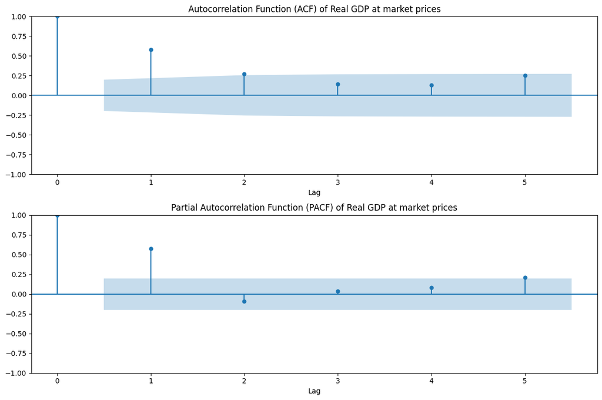

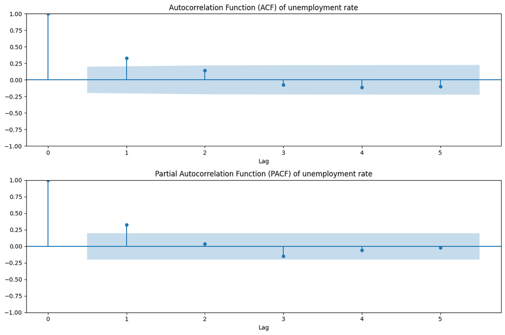

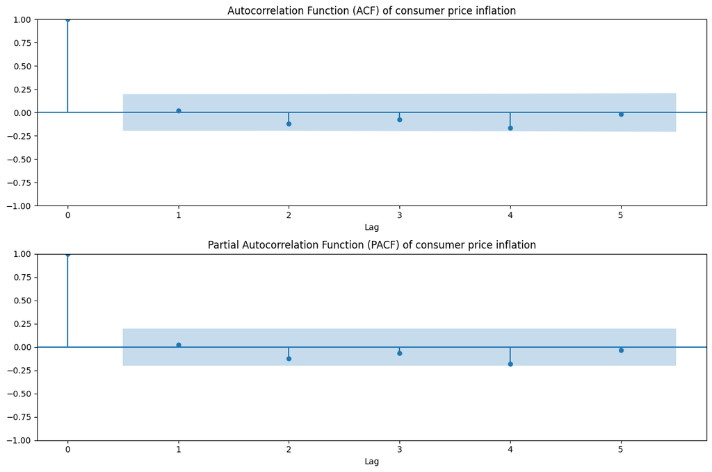

```python
import matplotlib.pyplot as plt
from statsmodels.graphics.tsaplots import plot_acf, plot_pacf

# Create a new DataFrame to hold the variables as stationary time series
df_stationary = df_part3.copy()

for column in df_stationary.columns:
    df_stationary[column] = df_stationary[column].diff()
    df_stationary.dropna(inplace=True)

# Loop over all columns in the DataFrame
for column in df_stationary.columns:
    fig, (ax1, ax2) = plt.subplots(2, 1, figsize=(12,8))

    # Plot the ACF
    plot_acf(df_stationary[column], ax=ax1, lags=5)
    ax1.set_title(f'Autocorrelation Function (ACF) of {column}')
    ax1.set_xlabel('Lag')

    # Plot the PACF
    plot_pacf(df_stationary[column], ax=ax2, lags=5)
    ax2.set_title(f'Partial Autocorrelation Function (PACF) of {column}')
    ax2.set_xlabel('Lag')

    plt.tight_layout()
    plt.show()
```

#### 38. Explain the principle of parsimony and its relationship with Ockham’s razor using the theory of information criterion.

The principle of parsimony suggests that preferring simpler models over more complex ones when both adequately fit the data is better. It's often called Ockham's razor.

#### 39. Explain the problem of auto-correlation of the errors.

Autocorrelation of errors, also known as serial correlation, refers to the presence of correlation among the error terms or residuals of a regression or time series model. This correlation violates the assumption of independence among residuals, which is crucial for the reliability of statistical inferences and model estimations.

#### 40. Using only stationary variables, run a regression of GDP on constant, unemployment and inflation and test the hypothesis of no-autocorrelation of errors.

PAG 582 - EXAMPLE 18.3 https://corporatefinanceinstitute.com/resources/data-science/durbin-watson-statistic/ The Durbin Watson statistic will always assume a value between 0 and 4. A value of DW = 2 indicates that there is no autocorrelation. First check if we are using only stationary variables.

```python
import statsmodels.api as sm
import statsmodels.formula.api as smf
from statsmodels.tsa.stattools import adfuller

# Check stationarity of variables
variables = ["Real GDP at market prices", "unemployment rate", "consumer price inflation"]
stationary_variables = []

# Replace missing values with the mean of the column
df_part3_copy = df_part3.copy()
df_part3_copy = df_part3_copy.fillna(df_part3_copy.mean())
for variable in variables:
    adf_result = adfuller(df_part3_copy[variable])
    print(f"ADF Test for {variable}: p-value = {adf_result[1]}")
    if adf_result[1] <= 0.05:
        print(f"{variable} is stationary.")
        stationary_variables.append(variable)
    else:
        print(f"{variable} is not stationary. Differencing...")
        df_part3_copy[f"{variable}_diff"] = df_part3_copy[variable].diff().dropna()
        stationary_variables.append(f"{variable}_diff")

# Run the regression only if all variables are stationary
if len(stationary_variables) == len(variables):
    model_formula = 'Q("' + stationary_variables[0] + '") ~ Q("' + stationary_variables[1] + '") + Q("' + stationary_variables[2] + '")'
    model = smf.ols(formula=model_formula, data=df_part3_copy)
    results = model.fit()

    # Print regression summary
    print(results.summary())

    # Test for autocorrelation of errors (example using Durbin-Watson test)
    dw_statistic = sm.stats.stattools.durbin_watson(results.resid)
    print(f"Durbin-Watson Statistic: {dw_statistic}")

    # Interpretation of Durbin-Watson Statistic
    if 1.5 < dw_statistic < 2.5:
        print("Durbin-Watson statistic suggests no significant autocorrelation.")
    elif dw_statistic <= 1.5:
        print("Durbin-Watson statistic suggests positive autocorrelation.")
    elif dw_statistic >= 2.5:
        print("Durbin-Watson statistic suggests negative autocorrelation.")
else:
    print("Not all variables are stationary. Consider transforming the variables.")
```

```
ADF Test for Real GDP at market prices: p-value = 1.0
Real GDP at market prices is not stationary. Differencing...
ADF Test for unemployment rate: p-value = 0.6830243987354911
unemployment rate is not stationary. Differencing...
ADF Test for consumer price inflation: p-value = 0.001168599408868904
consumer price inflation is stationary.
                                     OLS Regression Results
===============================================================================================
Dep. Variable:     Q("Real GDP at market prices_diff")   R-squared:                       0.218
Model:                                             OLS   Adj. R-squared:                  0.202
Method:                                  Least Squares   F-statistic:                     13.53
Date:                                 Tue, 12 Dec 2023   Prob (F-statistic):           6.56e-06
Time:                                         22:02:28   Log-Likelihood:                -1102.8
No. Observations:                                  100   AIC:                             2212.
Df Residuals:                                       97   BIC:                             2219.
Df Model:                                            2
Covariance Type:                             nonrobust
=================================================================================================
                                    coef    std err          t      P>|t|      [0.025      0.975]
-------------------------------------------------------------------------------------------------
Intercept                      1.168e+04   1876.767      6.225      0.000    7957.708    1.54e+04
Q("unemployment rate_diff")      18.0501      3.488      5.175      0.000      11.128      24.973
Q("consumer price inflation")  -284.6607    246.600     -1.154      0.251    -774.093     204.771
==============================================================================
Omnibus:                        6.928   Durbin-Watson:                   0.846
Prob(Omnibus):                  0.031   Jarque-Bera (JB):                6.524
Skew:                           0.562   Prob(JB):                       0.0383
Kurtosis:                       2.452   Cond. No.                         560.
==============================================================================

Notes:
[1] Standard Errors assume that the covariance matrix of the errors is correctly specified.
Durbin-Watson Statistic: 0.8461725976568517
Durbin-Watson statistic suggests positive autocorrelation.
```

```python
import statsmodels.api as sm
import statsmodels.formula.api as smf
from statsmodels.tsa.stattools import adfuller

# Check stationarity of variables
variables = ["Real GDP at market prices", "unemployment rate", "consumer price inflation"]
stationary_variables = []

df_part3_copy = df_part3.copy()

for variable in variables:
    adf_result = adfuller(df_part3_copy[variable])
    print(f"ADF Test for {variable}: p-value = {adf_result[1]}")
    if adf_result[1] <= 0.05:
        print(f"{variable} is stationary.")
        stationary_variables.append(variable)
    else:
        print(f"{variable} is not stationary. Differencing...")
        df_part3_copy[f"{variable}_diff"] = df_part3_copy[variable].diff().dropna()
        stationary_variables.append(f"{variable}_diff")

# Run the regression only if all variables are stationary
if len(stationary_variables) == len(variables):
    model_formula = 'Q("' + stationary_variables[0] + '") ~ Q("' + stationary_variables[1] + '") + Q("' + stationary_variables[2] + '")'
    model = smf.ols(formula=model_formula, data=df_part3_copy)
    results = model.fit()

    # Print regression summary
    print(results.summary())

    # Test for autocorrelation of errors (example using Durbin-Watson test)
    dw_statistic = sm.stats.stattools.durbin_watson(results.resid)
    print(f"Durbin-Watson Statistic: {dw_statistic}")

    # Interpretation of Durbin-Watson Statistic
    if 1.5 < dw_statistic < 2.5:
        print("Durbin-Watson statistic suggests no significant autocorrelation.")
    elif dw_statistic <= 1.5:
        print("Durbin-Watson statistic suggests positive autocorrelation.")
    elif dw_statistic >= 2.5:
        print("Durbin-Watson statistic suggests negative autocorrelation.")
else:
    print("Not all variables are stationary. Consider transforming the variables.")
```

```
ADF Test for Real GDP at market prices: p-value = 1.0
Real GDP at market prices is not stationary. Differencing...
ADF Test for unemployment rate: p-value = 0.6830243987354911
unemployment rate is not stationary. Differencing...
ADF Test for consumer price inflation: p-value = 0.001168599408868904
consumer price inflation is stationary.
                                     OLS Regression Results
===============================================================================================
Dep. Variable:     Q("Real GDP at market prices_diff")   R-squared:                       0.218
Model:                                             OLS   Adj. R-squared:                  0.202
Method:                                  Least Squares   F-statistic:                     13.53
Date:                                 Tue, 12 Dec 2023   Prob (F-statistic):           6.56e-06
Time:                                         22:02:28   Log-Likelihood:                -1102.8
No. Observations:                                  100   AIC:                             2212.
Df Residuals:                                       97   BIC:                             2219.
Df Model:                                            2
Covariance Type:                             nonrobust
=================================================================================================
                                    coef    std err          t      P>|t|      [0.025      0.975]
-------------------------------------------------------------------------------------------------
Intercept                      1.168e+04   1876.767      6.225      0.000    7957.708    1.54e+04
Q("unemployment rate_diff")      18.0501      3.488      5.175      0.000      11.128      24.973
Q("consumer price inflation")  -284.6607    246.600     -1.154      0.251    -774.093     204.771
==============================================================================
Omnibus:                        6.928   Durbin-Watson:                   0.846
Prob(Omnibus):                  0.031   Jarque-Bera (JB):                6.524
Skew:                           0.562   Prob(JB):                       0.0383
Kurtosis:                       2.452   Cond. No.                         560.
==============================================================================

Notes:
[1] Standard Errors assume that the covariance matrix of the errors is correctly specified.
Durbin-Watson Statistic: 0.8461725976568517
Durbin-Watson statistic suggests positive autocorrelation.
```

#### 42. For all variables, construct their lag 1 and lag 2 variables.

```python
# Assuming df is your DataFrame

# List of variables for which you want to construct lag variables
variables = ["Real GDP at market prices", "unemployment rate", "consumer price inflation"]

# Number of lags to create
lags = [1, 2]

df_part3_lag = df_part3.copy()

# Construct lag variables for each specified lag
for variable in variables:
    for lag in lags:
        df_part3_lag[f"{variable}_lag_{lag}"] = df_part3_lag[variable].shift(lag)

# Display the modified DataFrame with lag variables
df_part3_lag
```

| year | Real GDP at market prices | unemployment rate | consumer price inflation | Real GDP at market prices_lag_1 | Real GDP at market prices_lag_2 | unemployment rate_lag_1 | unemployment rate_lag_2 | consumer price inflation_lag_1 | consumer price inflation_lag_2 |
| --- | --- | --- | --- | --- | --- | --- | --- | --- | --- |
| 1900 | 1.811603e+05 | 16689.642547 | 4.058273 | NaN | NaN | NaN | NaN | NaN | NaN |
| 1901 | 1.849745e+05 | 16669.549581 | -0.300000 | 1.811603e+05 | NaN | 16689.642547 | NaN | 4.058273 | NaN |
| 1902 | 1.877566e+05 | 16764.901436 | 0.000000 | 1.849745e+05 | 1.811603e+05 | 16669.549581 | 16689.642547 | -0.300000 | 4.058273 |
| 1903 | 1.860158e+05 | 16834.531438 | 1.103310 | 1.877566e+05 | 1.849745e+05 | 16764.901436 | 16669.549581 | 0.000000 | -0.300000 |
| 1904 | 1.881556e+05 | 16749.127752 | -0.396825 | 1.860158e+05 | 1.877566e+05 | 16834.531438 | 16764.901436 | 1.103310 | 0.000000 |
| ... | ... | ... | ... | ... | ... | ... | ... | ... | ... |
| 1996 | 1.243709e+06 | 26060.000000 | 2.400308 | 1.212798e+06 | 1.183144e+06 | 25818.000000 | 25504.000000 | 2.656452 | 1.978490 |
| 1997 | 1.282602e+06 | 26526.000000 | 1.824606 | 1.243709e+06 | 1.212798e+06 | 26060.000000 | 25818.000000 | 2.400308 | 2.656452 |
| 1998 | 1.323527e+06 | 26795.000000 | 1.557398 | 1.282602e+06 | 1.243709e+06 | 26526.000000 | 26060.000000 | 1.824606 | 2.400308 |
| 1999 | 1.366983e+06 | 27168.000000 | 1.328710 | 1.323527e+06 | 1.282602e+06 | 26795.000000 | 26526.000000 | 1.557398 | 1.824606 |
| 2000 | 1.418176e+06 | 27484.000000 | 0.796456 | 1.366983e+06 | 1.323527e+06 | 27168.000000 | 26795.000000 | 1.328710 | 1.557398 |

101 rows × 9 columns

#### 43. Run a regression of GDP on constant, lag 1 unemployment, lag 2 unemployment, lag 1 inflation, lag 2 inflation. What is the number of observations and why?

$$ n - 2 $$

```python
import statsmodels.api as sm

# Assuming 'df' is your DataFrame

df_part3_lag_2 = df_part3.copy()

# Create lagged variables
df_part3_lag_2.loc[:, 'unemployment_rate_lag1'] = df_part3_lag_2['unemployment rate'].shift(1)
df_part3_lag_2.loc[:, 'unemployment_rate_lag2'] = df_part3_lag_2['unemployment rate'].shift(2)
df_part3_lag_2.loc[:, 'inflation_lag1'] = df_part3_lag_2['consumer price inflation'].shift(1)
df_part3_lag_2.loc[:, 'inflation_lag2'] = df_part3_lag_2['consumer price inflation'].shift(2)

# Drop rows with NaN values introduced by the shift
df_part3_lag_2 = df_part3_lag_2.dropna()

# Define the independent variables
X = df_part3_lag_2[['unemployment_rate_lag1', 'unemployment_rate_lag2', 'inflation_lag1', 'inflation_lag2']]

# Add a constant to the independent variables matrix
X = sm.add_constant(X)

# Define the dependent variable
y = df_part3_lag_2['Real GDP at market prices']

# Create the OLS model
model = sm.OLS(y, X)

# Fit the model
results = model.fit()

# Print the regression summary
print(results.summary())

# Number of observations
num_observations = len(df_part3_lag_2)
print(f"Number of observations: {num_observations}")
```

```
                                OLS Regression Results
=====================================================================================
Dep. Variable:     Real GDP at market prices   R-squared:                       0.667
Model:                                   OLS   Adj. R-squared:                  0.653
Method:                        Least Squares   F-statistic:                     47.02
Date:                       Tue, 12 Dec 2023   Prob (F-statistic):           1.20e-21
Time:                               22:02:28   Log-Likelihood:                -1349.0
No. Observations:                         99   AIC:                             2708.
Df Residuals:                             94   BIC:                             2721.
Df Model:                                  4
Covariance Type:                   nonrobust
==========================================================================================
                             coef    std err          t      P>|t|      [0.025      0.975]
------------------------------------------------------------------------------------------
const                  -1.561e+06   1.56e+05    -10.017      0.000   -1.87e+06   -1.25e+06
unemployment_rate_lag1    89.7223     55.079      1.629      0.107     -19.638     199.083
unemployment_rate_lag2     5.0809     55.003      0.092      0.927    -104.129     114.290
inflation_lag1         -6770.6855   5804.586     -1.166      0.246   -1.83e+04    4754.456
inflation_lag2           194.1521   5925.185      0.033      0.974   -1.16e+04     1.2e+04
==============================================================================
Omnibus:                        2.831   Durbin-Watson:                   0.035
Prob(Omnibus):                  0.243   Jarque-Bera (JB):                1.780
Skew:                           0.047   Prob(JB):                        0.411
Kurtosis:                       2.350   Cond. No.                     2.41e+05
==============================================================================

Notes:
[1] Standard Errors assume that the covariance matrix of the errors is correctly specified.
[2] The condition number is large, 2.41e+05. This might indicate that there are
strong multicollinearity or other numerical problems.
Number of observations: 99
```

#### 44. State and test the no-Granger causality hypothesis of inflation on GDP at the 10% level

```python
from statsmodels.tsa.stattools import grangercausalitytests

df_part3_granger = df_part3.copy()

# Define the maximum number of lags to test for Granger causality
maxlag = 2

# Run the Granger causality test
test_result = grangercausalitytests(df_part3_granger[['Real GDP at market prices', 'consumer price inflation']], maxlag)

# Extract the p-values for each lag
p_values = [round(test_result[i+1][0]['ssr_ftest'][1],4) for i in range(maxlag)]

print("\n")
# Print the p-values
print('p-values for each lag are: ', p_values)

# Check if p-value is less than 0.10 at each lag
for i in range(maxlag):
    if p_values[i] < 0.10:
        print(f"At lag {i+1}, we reject the null hypothesis that inflation does not Granger-cause GDP at the 10% significance level.")
    else:
        print(f"At lag {i+1}, we fail to reject the null hypothesis that inflation does not Granger-cause GDP at the 10% significance level.")
```

```
Granger Causality
number of lags (no zero) 1
ssr based F test:         F=6.1783  , p=0.0146  , df_denom=97, df_num=1
ssr based chi2 test:   chi2=6.3694  , p=0.0116  , df=1
likelihood ratio test: chi2=6.1747  , p=0.0130  , df=1
parameter F test:         F=6.1783  , p=0.0146  , df_denom=97, df_num=1

Granger Causality
number of lags (no zero) 2
ssr based F test:         F=1.9766  , p=0.1443  , df_denom=94, df_num=2
ssr based chi2 test:   chi2=4.1635  , p=0.1247  , df=2
likelihood ratio test: chi2=4.0783  , p=0.1301  , df=2
parameter F test:         F=1.9766  , p=0.1443  , df_denom=94, df_num=2


p-values for each lag are:  [0.0146, 0.1443]
At lag 1, we reject the null hypothesis that inflation does not Granger-cause GDP at the 10% significance level.
At lag 2, we fail to reject the null hypothesis that inflation does not Granger-cause GDP at the 10% significance level.
```

#### 45. Divide the sample in two groups: 1900-1950 and 1951-2000. Test the stability of coefficients between the two periods.

```python
from scipy.stats import f
import pandas as pd
import statsmodels.api as sm
import numpy as np

df_part3_45 = df_part3.copy()

# Drop NaN values and replace inf values
df_part3_45 = df_part3_45.dropna()
df_part3_45 = df_part3_45.replace([np.inf, -np.inf], np.nan).dropna()

# Split the data into two periods
df_1900_1950 = df_part3_45.loc[1900:1950]
df_1951_2000 = df_part3_45.loc[1951:2000]

# Regression for the first period (1900-1950)
X_1900_1950 = sm.add_constant(df_1900_1950[['unemployment rate', 'consumer price inflation']])
y_1900_1950 = df_1900_1950['Real GDP at market prices']
model_1900_1950 = sm.OLS(y_1900_1950, X_1900_1950).fit()

# Regression for the second period (1951-2000)
X_1951_2000 = sm.add_constant(df_1951_2000[['unemployment rate', 'consumer price inflation']])
y_1951_2000 = df_1951_2000['Real GDP at market prices']
model_1951_2000 = sm.OLS(y_1951_2000, X_1951_2000).fit()

# Calculate the RSS for each period
RSS_1900_1950 = np.sum(model_1900_1950.resid ** 2)
RSS_1951_2000 = np.sum(model_1951_2000.resid ** 2)


# Now you can fit your model
X = sm.add_constant(df_part3_45[['unemployment rate', 'consumer price inflation']])
y = df_part3_45['Real GDP at market prices']
model = sm.OLS(y, X).fit()

# Calculate the RSS for the entire dataset
RSS_pooled = np.sum(model.resid ** 2)

# Calculate the Chow test statistic
N1, K1 = X_1900_1950.shape
N2, K2 = X_1951_2000.shape
F = ((RSS_pooled - (RSS_1900_1950 + RSS_1951_2000)) / (RSS_1900_1950 + RSS_1951_2000)) * ((N1 + N2 - 2*K1) / K1)

# Calculate the p-value
p_value = f.sf(F, K1, N1 + N2 - 2*K1)

# Print the results
print(f"Chow Test Statistic: {F}")
print(f"P-Value: {p_value}")

# Check if the p-value is below a significance level (e.g., 0.05) to determine stability
if p_value < 0.05:
    print("The coefficients are significantly different between the two periods, indicating instability.")
else:
    print("There is no significant difference in coefficients between the two periods, indicating stability.")
```

```
Chow Test Statistic: 61.4079730847121
P-Value: 3.675497383039281e-22
The coefficients are significantly different between the two periods, indicating instability.
```

The instability of the coefficients suggests that the economic relationships represented by the model have not remained constant over the century. This could be due to a variety of factors, such as changes in economic policy, technology, or societal factors.

Using the function:

```
Chow Test Statistic = ((RSS_pooled - (RSS1 + RSS2)) / k) / ((RSS1 + RSS2) / (n1 + n2 - 2k))
```

Looking closer to the sumarry of the regression that we made for the two periods we have the next points:

1. **R-squared**: The R-squared value for the 1900-1950 period is 0.968,and for the 1951-2000 period, the R-squared value is 0.689. The model fits the data better in the 1900-1950 period.
2. **Coefficients**: For the consumer price inflation, the coefficient is -726.7026 in the 1900-1950 period and 1076.6194 in the 1951-2000 period. This suggests that a unit increase in the consumer price inflation has a negative effect on Real GDP in the 1900-1950 period, but a positive effect in the 1951-2000 period.

For the unemployment rate, the coefficient is 24.1919 in the 1900-1950 period and 260.1245 in the 1951-2000 period. This suggests that a unit increase in the unemployment rate has a larger effect on Real GDP in the 1951-2000 period.

For the 1900-1950 period, we have that:

$$ y = -2.255e+05 + 24.1919x_1 - 726.7026x_2 + u $$

And for the 1951-2000 period, whe have:

$$ y = -5.708e+06 + 260.1245x_1 + 1076.6194x_2 + u $$

```python
# Print the summary of the regression for the first period (1900-1950)
print(model_1900_1950.summary())
```

```
                                OLS Regression Results
=====================================================================================
Dep. Variable:     Real GDP at market prices   R-squared:                       0.968
Model:                                   OLS   Adj. R-squared:                  0.967
Method:                        Least Squares   F-statistic:                     731.8
Date:                       Tue, 12 Dec 2023   Prob (F-statistic):           1.11e-36
Time:                               22:02:28   Log-Likelihood:                -542.95
No. Observations:                         51   AIC:                             1092.
Df Residuals:                             48   BIC:                             1098.
Df Model:                                  2
Covariance Type:                   nonrobust
============================================================================================
                               coef    std err          t      P>|t|      [0.025      0.975]
--------------------------------------------------------------------------------------------
const                    -2.255e+05    1.3e+04    -17.369      0.000   -2.52e+05   -1.99e+05
unemployment rate           24.1919      0.663     36.474      0.000      22.858      25.525
consumer price inflation  -726.7026    225.660     -3.220      0.002   -1180.423    -272.982
==============================================================================
Omnibus:                       19.109   Durbin-Watson:                   0.591
Prob(Omnibus):                  0.000   Jarque-Bera (JB):               36.953
Skew:                          -1.058   Prob(JB):                     9.46e-09
Kurtosis:                       6.593   Cond. No.                     1.76e+05
==============================================================================

Notes:
[1] Standard Errors assume that the covariance matrix of the errors is correctly specified.
[2] The condition number is large, 1.76e+05. This might indicate that there are
strong multicollinearity or other numerical problems.
```

#### 46. Test the structural breakpoint using a trim ratio of 25% at the 10% level

```python
import numpy as np
import pandas as pd
import statsmodels.api as sm
from scipy.stats import f

df_part3_46 = df_part3.copy()

# Split the data into two periods
df_1900_1950 = df_part3_46.loc[1900:1950]
df_1951_2000 = df_part3_46.loc[1951:2000]

# Fit models for each period
X1 = sm.add_constant(df_1900_1950[['unemployment rate', 'consumer price inflation']])
y1 = df_1900_1950['Real GDP at market prices']
model1 = sm.OLS(y1, X1).fit()

X2 = sm.add_constant(df_1951_2000[['unemployment rate', 'consumer price inflation']])
y2 = df_1951_2000['Real GDP at market prices']
model2 = sm.OLS(y2, X2).fit()

# Calculate the residuals for each period
residuals1 = model1.resid
residuals2 = model2.resid

# Trim the data based on the specified trim ratio (25% from each end)
trim_ratio = 0.25
trim_size1 = int(len(residuals1) * trim_ratio)
trim_size2 = int(len(residuals2) * trim_ratio)

trimmed_residuals1 = residuals1[trim_size1:-trim_size1]
trimmed_residuals2 = residuals2[trim_size2:-trim_size2]

# Calculate the RSS for trimmed residuals
RSS1 = np.sum(trimmed_residuals1**2)
RSS2 = np.sum(trimmed_residuals2**2)

# Fit a model for the pooled data
X_pooled = sm.add_constant(df_part3_46[['unemployment rate', 'consumer price inflation']])
y_pooled = df_part3_46['Real GDP at market prices']
model_pooled = sm.OLS(y_pooled, X_pooled).fit()

# Calculate the RSS for the pooled model
RSS_pooled = model_pooled.ssr

# Define N1, N2, K1, K2
N1, K1 = X1.shape
N2, K2 = X2.shape

# Define K (number of parameters)
K = K1 + K2

# Calculate the Chow test statistic
F_chow = ((RSS_pooled - (RSS1 + RSS2)) / K) / ((RSS1 + RSS2) / (N1 + N2 - 2 * K))

# Calculate the p-value
p_value_chow = f.sf(F_chow, K, N1 + N2 - 2 * K)

# Print the results
print(f"Chow Test Statistic: {F_chow}")
print(f"P-Value: {p_value_chow}")

# Check if the p-value is below the significance level (e.g., 0.10)
if p_value_chow < 0.10:
    print("There is evidence of a structural break.")
else:
    print("There is no evidence of a structural break.")
```

```
Chow Test Statistic: 57.71164968595683
P-Value: 1.4247823838970364e-28
There is evidence of a structural break.
```